# Introducción Rápída a R

Irán Apolinar Peredo Cortes

iranapolinar@hotmail.com

Presentamos una introducción rápida a R con los comando básicos más utilizados en el lenguaje utilizados en el análisis estadístico. Estas notas estarán disponibles en el siguiente enlace: https://github.com/IranNash/.

## Operaciones Básicas

En R podemos llamar a librerías con el comando `library(paquete)`, así como instalar paquetes con `install.packages("paquete", dependencies = c("Depends", "Suggests"))`. Para solicitar información de un comando podemos utilizar `help(paquete)`. Podemos introducir comentarios dentro del código anteponiendo un `#` al comentario sin que afecte la ejecución.

```r
a<-10
b<-20
c<-15
```

La asignación de valores en R se da mediante el simbolo `<-`, tambien puede ser utilizado el simbolo `=`. La suma, resta, multiplización y división utilizan `+, -, *` y `/` respectivamente. La jerarquía de operaciones puede ser definitida utilizando parentesis.

```r
a+b #suma
```

```
## [1] 30
```

```r
a-b #resta
```

```
## [1] -10
```

```r
a*b #multiplicación
```

```
## [1] 200
```

```r
a/b #división
```

```
## [1] 0.5
```

```r
a+((b/c)*(c-a))*a #jerarquía de operaciones
```

```
## [1] 76.66667
```

Para **imprimir texto** en pantalla utilizamos el comando `print("texto")`, tambien se puede utilizar para mostrar el valor guardado en variables. Podemos concatenar texto con variables con los comandos `paste()` o concatenar texto con varias variables u operaciones con el comando `sprintf()`y `%s`. Finalmente se puede utilizar `cat("texto", variable, "texto", variable)` para facilitar la impresión cuando hay muchas variables.

```r
a<-10
b<-20
print("Hola")
```

```
## [1] "Hola"
```

```r
print(a)
```

```
## [1] 10
```

```r
print(paste("el dato a vale:", a))
```

```
## [1] "el dato a vale: 10"
```

```r
sprintf("la suma de a + b es %s,y la de a-b es %s",a+b, a-b)
```

```
## [1] "la suma de a + b es 30,y la de a-b es -10"
```

```r
cat("a es igual a:", a, "la suma de a + b es:", a+b)
```

```
## a es igual a: 10 la suma de a + b es: 30
```

Para introducir **datos boleanos**, es decir, que tienen como salida verdadero o falso utilizamos los operadores `<,>,==, >= o <=`. Tamien es posible guardar un dato boleano mediante `<-` y luego imprimirlo en pantalla con `print()` como sigue:

```r
a == 10
```

```
## [1] TRUE
```

```r
b >= 20
```

```
## [1] TRUE
```

```r
c < a
```

```
## [1] FALSE
```

```r
d <- a == 20
print(a)
```

```
## [1] 10
```

El **módulo o residuo** de una división se optiene con el comando `%%`. Para **truncar** a enteros un número se utiliza el comando `trunc()`:

```r
a <- 41
a%%2
```

```
## [1] 1
```

```r
trunc(14.98765)
```

```
## [1] 14
```

Cuando se realizan programas es común solicitar la introducción de datos desde el teclado y que se almacene en alguna variable. Para poder introducir datos numéricos en R utilizamos el comando `scan(n=1)` se debe especificar el número de datos a introducir. Para introducir datos de texto utilizamos junto con `scan(n=1)` el comando `what =` y especificamos que el tipo de datos es un character (este ejemplo se recomienda correrlo en su terminal de R).

```r
d<-scan(n=1) #Tecleamos el número 5
print(d)
```

```
## numeric(0)
```

```r
ch<-scan(n=1, what = "character") #Tecleamos hola
print(ch)
```

```
## character(0)
```

Las condicionales en R utiliza el comando `if(){}` y `else{}`, se establece la condición entre parentesis `()` y finalmente entre llaves `{}` se introduce lo que debe de realizarse si se cumple la condición. Por ejemplo, supongamos que `a` es igual a 10. Si esto se cumple, entonces de imprime el texto `a es igual a 10`. Para este ejemplo utilizamos el operador `==` que se utiliza para *preguntar* si una variable es igual a otra, en este caso, si una variable es igual a un número:

```r
a <- 10
if (a == 10){
  print("a es igual a 10")
}
```

```
## [1] "a es igual a 10"
```

```r
a<-10
b<-20
h<-0
g<-0
if(a>5){
  h<-a*b
}else{
  g<-a-b
}
print(h)
```

```
## [1] 200
```

```r
print(g)
```

```
## [1] 0
```

Se puede realizar la condicional en su forma corta de la siguiente manera:

```r
a<-10
b<-20
h<-0
g<-0
if(a > 5) h <- a*b else g <- a-b
print(h)
```

```
## [1] 200
```

```r
print(g)
```

```
## [1] 0
```

En R se pueden utilizar tres tipos de **ciclos(bucles o loops)**. Utilizamos el comando `while(){}` para que un ciclo se repita mientras se cumple una condición. Normalmente este tipo de ciclos utiliza contadores, es decir, variables auxiliares donde especificamos donde empieza a contar el ciclo. Dentro del ciclo generalmente especificamos los incrementos del contador. Finalmente el ciclo se repetirá hasta que el contador cumpla la condición.

Por ejemplo, realicemos un ciclo que permita repetir 8 veces la frase `mi primer ciclo en R`. El código para este ejemplo es como sigue:

```r
i <- 1 #contador
while(i <= 8){
  print("mi primer ciclo en R")
  i = i +1
}
```

```
## [1] "mi primer ciclo en R"
## [1] "mi primer ciclo en R"
## [1] "mi primer ciclo en R"
## [1] "mi primer ciclo en R"
## [1] "mi primer ciclo en R"
## [1] "mi primer ciclo en R"
## [1] "mi primer ciclo en R"
## [1] "mi primer ciclo en R"
```

Si leyeramos el código este diría “definimos un contador `i = 1`. Mientras el contador `i` sea menor o igual a `8`” entonces imprime `mi primer ciclo en R`. Ahora suma al contador `i` una unidad para que en el siguiente ciclo valga 2" y así sucesivamente.

Realicemos el mismo ejemplo con un ciclo `for(){}`. En este caso definimos dentro de la condición el contador y le decimos el rango que va a recorrer. Finalmente le decimos en que hacer en cada ciclo. El código para realizar el mismo ejercicio es el siguiente:

```r
for(i in 1:8){
  print("mi primer ciclo en R")
}
```

```
## [1] "mi primer ciclo en R"
## [1] "mi primer ciclo en R"
## [1] "mi primer ciclo en R"
## [1] "mi primer ciclo en R"
## [1] "mi primer ciclo en R"
## [1] "mi primer ciclo en R"
## [1] "mi primer ciclo en R"
## [1] "mi primer ciclo en R"
```

Como podemos ver el código es más simple. Tenemos un contador `i` que va a recorrer de 1 a 8, es decir, ocho veces se repetirá la instrucción `print("mi primer ciclo en R")` se sabe que son 8 porqué se ha especificado con el código `in 1:8` para comprobarlo basta con imprimir `i` en pantalla

```r
print(i)
```

```
## [1] 8
```

Se puede realizar el ciclo también es su forma corta de la siguiente manera:

```r
for(i in 1:8) print("mi primer ciclo en R")
```

```
## [1] "mi primer ciclo en R"
## [1] "mi primer ciclo en R"
## [1] "mi primer ciclo en R"
## [1] "mi primer ciclo en R"
## [1] "mi primer ciclo en R"
## [1] "mi primer ciclo en R"
## [1] "mi primer ciclo en R"
## [1] "mi primer ciclo en R"
```

Se pueden tambien agregar instrucciones posteriores en la misma linea de código utilizando `;` se esta manera:

```r
a<-10
b<-20
h<-0
g<-0
if(a > 5) h <- a*b else g <- a-b ; cat("el valor de h es:", h)
```

```
## el valor de h es: 200
```

## Vectores y Matrices

Podemos crear un vector con el comando `c()` y asignarlo a una variable. Podemos hacer una secuencia de numeros dentro de un vector utilizando la nomenclatura `c(j:k)` para que el vector tome los valores de `j` hasta`k`. Tambien es posible crear un vector de ceros con el comando `numeric()` especificando el número de ceros, es decir el tamaño del vector:

```r
x<-c(1,2,3,4,5)
print(x)
```

```
## [1] 1 2 3 4 5
```

```r
x<-c(5:10)
print(x)
```

```
## [1]  5  6  7  8  9 10
```

```r
x<- numeric(5)
print(x)
```

```
## [1] 0 0 0 0 0
```

Para conocer el contido del vector podemos utilizar `str()`:

```r
x<-c(1.1,2,3,4,5)
str(x)
```

```
##  num [1:5] 1.1 2 3 4 5
```

Como se observa es de tipo numérico del con 5 datos. Para buscar un dato específico dentro del vector utilizamos la nomenclatura `x[i]` donde `i` es la posición del elemento que buscamos. Podemo extraer más de un nímero con el comando `c(i,j,k)` donde `ì`, `j`, `k` nos muestran la posición de los datos a extraer:

```r
x<-c(3,4,5,6,7,8,9,10,11)
print(x)
```

```
## [1]  3  4  5  6  7  8  9 10 11
```

```r
x[2]
```

```
## [1] 4
```

```r
x[c(2,4,6)]
```

```
## [1] 4 6 8
```

Podemos realizar operaciones aritméticas con los elementos de un vector como restarle o sumarle un número a cada elemento, multiplicar cada elemento por un número dado o elevar cada elemento a una cierta potencia:

```r
x<-c(1,2,3,4,5,6,7,8,9)
print(x)
```

```
## [1] 1 2 3 4 5 6 7 8 9
```

```r
x+5 #resta
```

```
## [1]  6  7  8  9 10 11 12 13 14
```

```r
x-3 #suma
```

```
## [1] -2 -1  0  1  2  3  4  5  6
```

```r
x*2 #multiplicación
```

```
## [1]  2  4  6  8 10 12 14 16 18
```

```r
x^2 #potencia
```

```
## [1]  1  4  9 16 25 36 49 64 81
```

```r
x**2 #potencia
```

```
## [1]  1  4  9 16 25 36 49 64 81
```

Estas mismas operaciones pueden realizarse entre vectores, por ejemplo:

```r
x<-c(1,2,3,4,5,6,7,8,9)
y<-c(3,4,5,6,7,8,9,10,11)
x+y
```

```
## [1]  4  6  8 10 12 14 16 18 20
```

```r
x-y
```

```
## [1] -2 -2 -2 -2 -2 -2 -2 -2 -2
```

```r
x*y
```

```
## [1]  3  8 15 24 35 48 63 80 99
```

```r
x^y
```

```
## [1]           1          16         243        4096       78125     1679616
## [7]    40353607  1073741824 31381059609
```

Puede ocurrir que un vector contenga datos faltantes, para calcular algunas operaciones estadísticas en presencia de `NA` utilizamos `na.rm = TRUE`:

```r
a<-c(1,NA,3,4,5,NA,7,8,1,2,3,4,5,6,7,8,9)
sum(is.na(a)) # número de NA es los datos
```

```
## [1] 2
```

```r
mean(a, na.rm = TRUE) #media
```

```
## [1] 4.866667
```

```r
median(a, na.rm = TRUE) #mediana
```

```
## [1] 5
```

```r
min(a, na.rm = TRUE) #mínimo
```

```
## [1] 1
```

```r
max(a, na.rm = TRUE) #máximo
```

```
## [1] 9
```

```r
range(a, na.rm = TRUE) #minimo y máximo
```

```
## [1] 1 9
```

```r
sd(a, na.rm = TRUE) # error estandar
```

```
## [1] 2.587516
```

Los cuartiles pueden ser personalizados utilizando `quantile()`

```r
a<-c(1,2,3,4,5,6,7,8,91,2,3,4,5,6,7,8,9)
quantile(a,probs = c(0,0.25, 0.5, 0.75,1))#Estilo clásico
```

```
##   0%  25%  50%  75% 100%
##    1    3    5    7   91
```

```r
quantile(a,probs = c(0,.2,.9,1))#Estilo pareto
```

```
##   0%  20%  90% 100%
##  1.0  3.0  8.4 91.0
```

Podemos ordenar los vectores con el comando `sort()`, de igual manera podemos conocer su ubicación con `order()`. El problema que presenta `order()` es que no toma en cuenta la repetición de los datos, esto se puede solucionar con `rank()`.

```r
a<-c(1,2,3,4,5,6,7,8,9,1,2,3,4,5,6,7,8,9,9)
sort(a) #Ordena de menor a mayor
```

```
##  [1] 1 1 2 2 3 3 4 4 5 5 6 6 7 7 8 8 9 9 9
```

```r
sort(a, decreasing = TRUE) #ordena de mayor a menor
```

```
##  [1] 9 9 9 8 8 7 7 6 6 5 5 4 4 3 3 2 2 1 1
```

```r
order(a) #ordena de mayor a menor
```

```
##  [1]  1 10  2 11  3 12  4 13  5 14  6 15  7 16  8 17  9 18 19
```

```r
rank(a)
```

```
##  [1]  1.5  3.5  5.5  7.5  9.5 11.5 13.5 15.5 18.0  1.5  3.5  5.5  7.5  9.5
## [15] 11.5 13.5 15.5 18.0 18.0
```

```r
rank(a, ties.method = "min")
```

```
##  [1]  1  3  5  7  9 11 13 15 17  1  3  5  7  9 11 13 15 17 17
```

```r
rank(a, ties.method = "max")
```

```
##  [1]  2  4  6  8 10 12 14 16 19  2  4  6  8 10 12 14 16 19 19
```

En ocaciones requerimos la suma acumulada de un vector o el producto de todos sus elementos, para estos casos podemos utilizar `cumsum()` o `cumprod()`.

```r
v = c(1,2,3,4,5,6,7,8)
cumsum(v)
```

```
## [1]  1  3  6 10 15 21 28 36
```

```r
cumprod(v)
```

```
## [1]     1     2     6    24   120   720  5040 40320
```

Para saber si algún elemento de un vector se encuentra dentro de otro podemos utizar el operador `%in%` el cual nos devuelve un vector de boleanos. Podemos saber en que posición están con `which()`

```r
v = c(1,2,3,4,5,6,7,12)
w = c(2,4,6,8,10,12,14)
v %in% w
```

```
## [1] FALSE  TRUE FALSE  TRUE FALSE  TRUE FALSE  TRUE
```

```r
which(v %in% w)
```

```
## [1] 2 4 6 8
```

Esto muestra que el elemento de la posición 2,4,6,8 del vector v, pertenecen al vector w. Podemos tambien crear vectores de caracteres, por ejemplo, supongamos que queremos introducir en un vector el genero de 9 personas, bastaría con introducir entre comillas `" "` el caracter correspondiente.

```r
sexo <- c("hombre", "mujer", "mujer", "otro", "hombre", "hombre", "mujer", "mujer", "otro")
print(sexo)
```

```
## [1] "hombre" "mujer"  "mujer"  "otro"   "hombre" "hombre" "mujer"  "mujer"
## [9] "otro"
```

En la practica es común preguntarse si la variable es un factor, esto permite crear categorías dentro del vector. Para esto utilizamos el comando `is.factor()` para comprobar si es factor y `as.factor()` para transformar.

```r
is.factor(sexo)
```

```
## [1] FALSE
```

```r
sexo<-as.factor(sexo)
is.factor(sexo)
```

```
## [1] TRUE
```

Como vemos en la prmera salida `is.factor(sexo)` muestra un `FALSE` lo que significa que no es un factor, es decir, el vector no tiene categorías. Posteriormente con el comando `as.factor(sexo)` se vuelve a guardar en `sexo` con lo cual remplazamos la variable original por la variable con factores. Ahora si mandamos a imprimir `sexo` tenemos:

```r
print(sexo)
```

```
## [1] hombre mujer  mujer  otro   hombre hombre mujer  mujer  otro
## Levels: hombre mujer otro
```

nos muestra los tres niveles. Esto será importante cuando se trabaje con variables categóricas. Podemos generar una **matriz** a partir de combinación de varios vectores o contruirla directamente. Para el primer caso. Supongamos que creamos un vector con las estaturas de 9 personas, como en el caso anterior:

```r
est<-c(1.85, 1.64, 1.56, 1.71, 1.79, 1.81, 1.56, 1.63, 1.69)
print(est)
```

```
## [1] 1.85 1.64 1.56 1.71 1.79 1.81 1.56 1.63 1.69
```

Con el comado `rbind()` podemos combinar dos vectores y ordenarlos como filas. Con el comando `cbind()` hacemos los mismo pero lo ordenamos como columnas.

```r
A<-cbind(sexo, est)
print(A)
```

```
##       sexo  est
##  [1,]    1 1.85
##  [2,]    2 1.64
##  [3,]    2 1.56
##  [4,]    3 1.71
##  [5,]    1 1.79
##  [6,]    1 1.81
##  [7,]    2 1.56
##  [8,]    2 1.63
##  [9,]    3 1.69
```

```r
B<-rbind(sexo, est)
print(B)
```

```
##      [,1] [,2] [,3] [,4] [,5] [,6] [,7] [,8] [,9]
## sexo 1.00 2.00 2.00 3.00 1.00 1.00 2.00 2.00 3.00
## est  1.85 1.64 1.56 1.71 1.79 1.81 1.56 1.63 1.69
```

Como puede observarse la variable `sexo` ha sido remplazada por numero del 1 al 3, esto significa que se ha asignado la categoría correspondiente. Esto es útil en el momento de hacer modelos o gráficos.

Para hacer una matriz directamente utilizamos el comando `matrix()` en el cual establecemos el número de filas `nrow` y el número de columnas `ncol` los datos de la matriz se introducen como si fuera un vector. La dimensión de la matriz se muestra con el comando `dim()`

```r
A <- matrix(c(1,2,3,4,5,6), nrow = 2, ncol = 3)
print(A)
```

```
##      [,1] [,2] [,3]
## [1,]    1    3    5
## [2,]    2    4    6
```

```r
dim(A)
```

```
## [1] 2 3
```

Las operaciones operaciones elementales con matrices se realizan de la siguiente forma:

```r
A <- matrix(c(1,2,3,4), nrow = 2, ncol = 2)
B <- matrix(c(10,11,12,13), nrow = 2, ncol = 2)
t(A) #Transpuesta
```

```
##      [,1] [,2]
## [1,]    1    2
## [2,]    3    4
```

```r
A*3  #Multiplicación Escalar
```

```
##      [,1] [,2]
## [1,]    3    9
## [2,]    6   12
```

```r
A+B  #Suma de matrices
```

```
##      [,1] [,2]
## [1,]   11   15
## [2,]   13   17
```

```r
A-B  #Resta de matrices
```

```
##      [,1] [,2]
## [1,]   -9   -9
## [2,]   -9   -9
```

```r
A%*%B  #Producto Matricial
```

```
##      [,1] [,2]
## [1,]   43   51
## [2,]   64   76
```

```r
solve(A) #Matriz Inversa
```

```
##      [,1] [,2]
## [1,]   -2  1.5
## [2,]    1 -0.5
```

La matriz identidad se logra con el comando `diag()` donde especificamos el tamaño de la matriz. Por ejemplo una matriz identidad de 5x5 se realiza como:

```r
diag(5)
```

```
##      [,1] [,2] [,3] [,4] [,5]
## [1,]    1    0    0    0    0
## [2,]    0    1    0    0    0
## [3,]    0    0    1    0    0
## [4,]    0    0    0    1    0
## [5,]    0    0    0    0    1
```

Podemos recorrer los elementos de una matriz con un ciclo `for()` por ejemplo. Supongamos que tenemos tenemos una matriz de ceros de 5 variables y 10 filas y queremos llenar esa matriz con números aleatorios entre cierto rango, por ejemplo, numeros entre -2 y 2.

```r
s <- matrix(0, 10,5) #matriz de ceros de 10 x 5
for (i in 1:10) { #recorremos las filas
  for (j in 1:5) { #recorremos las columnas
    s[i,j] <- runif(1, -2, 2) #seguarda en la fila i, columna j
  }
}
print(s)
```

```
##              [,1]        [,2]       [,3]        [,4]        [,5]
##  [1,] -0.66090773  0.97153596 -0.1128715 -0.04754698  0.09208786
##  [2,]  0.51110300  1.14188042  1.0521036  0.04276043  0.22467017
##  [3,] -0.63387725  0.58890015  1.6007728 -1.16635775  0.85085083
##  [4,]  1.45104202 -1.50534802 -0.3021379 -1.51828790  1.52367597
##  [5,] -1.95290819 -1.41354749 -1.2829017  1.11799293 -0.15092733
##  [6,] -0.13110667  0.12810704 -1.2446282  0.21054921 -0.57229393
##  [7,] -0.78557147  0.55618006 -1.0822871  1.32639209  1.27826918
##  [8,] -1.96729705  1.56831648  1.7714339 -1.99369325  1.78108171
##  [9,]  0.32103553 -0.05566412  0.4592027  0.25255861  0.97070403
## [10,]  0.02851462 -1.49643108 -1.4251526 -1.63059067 -0.01765290
```

## Dataframe

Un data frame es un arreglo rectangular que permite almacenar distintos tipos de datos, tanto numéricos como de caracter. Una forma sencilla de hacerlo es a partir de vectores, por ejemplo:

```r
sexo <- c("hombre", "mujer", "mujer", "otro", "hombre", "hombre", "mujer", "mujer", "otro")
est<-c(1.85, 1.64, 1.56, 1.71, 1.79, 1.81, 1.56, 1.63, 1.69)
edad <- c(18, 20, 23, 25, 22, 18, 17, 19, 20)
data <- data.frame(sexo, est, edad)
print(data)
```

```
##     sexo  est edad
## 1 hombre 1.85   18
## 2  mujer 1.64   20
## 3  mujer 1.56   23
## 4   otro 1.71   25
## 5 hombre 1.79   22
## 6 hombre 1.81   18
## 7  mujer 1.56   17
## 8  mujer 1.63   19
## 9   otro 1.69   20
```

La estructura de los datos se obtiene con el comando `str()`:

```r
str(data)
```

```
## 'data.frame':    9 obs. of  3 variables:
##  $ sexo: Factor w/ 3 levels "hombre","mujer",..: 1 2 2 3 1 1 2 2 3
##  $ est : num  1.85 1.64 1.56 1.71 1.79 1.81 1.56 1.63 1.69
##  $ edad: num  18 20 23 25 22 18 17 19 20
```

Las estadísticas básicas del dataframe se obtiene con el comando `summary()`:

```r
summary(data)
```

```
##      sexo        est             edad
##  hombre:3   Min.   :1.560   Min.   :17.00
##  mujer :4   1st Qu.:1.630   1st Qu.:18.00
##  otro  :2   Median :1.690   Median :20.00
##             Mean   :1.693   Mean   :20.22
##             3rd Qu.:1.790   3rd Qu.:22.00
##             Max.   :1.850   Max.   :25.00
```

Podemos guardar los datos en formato .txt con el comando `write.table`. Se debe especificar el nombre del archivo así como el tipo de separación de los datos y si tiene o no encabezado entre otras definiciones, como sigue:

```r
write.table(data, file = "data.txt", sep = ",", col.names = TRUE)
```

Para poder llamar una base de datos podemo utilizar `read.table()` si es en formato `.txt`. Podemos llamar un `.csv` con `read.csv()`. Recordemos que para tener todas las especificaciones del comando basta con teclear `help("read.csv")` para tener todas las funciones.

```r
data<-read.table("data.txt", header = TRUE, sep = ",")
help("read.csv")
```

Para llamar una variable específica dentro del data.frame utilizamos el simbolo `$` después del nombre del data.frame.

```r
data$sexo
```

```
## [1] hombre mujer  mujer  otro   hombre hombre mujer  mujer  otro
## Levels: hombre mujer otro
```

```r
summary(data$est)
```

```
##    Min. 1st Qu.  Median    Mean 3rd Qu.    Max.
##   1.560   1.630   1.690   1.693   1.790   1.850
```

Finalmente, cuando se trabajan con bases de datos con muchas variables, puede llegar a ser complicado utilizar el simbolo `$` anteponiendolo al nombre de la base para llamar variables. En su lugar podemos utilizar el comando `attach()`

```r
attach(data)
summary(est)
```

```
##    Min. 1st Qu.  Median    Mean 3rd Qu.    Max.
##   1.560   1.630   1.690   1.693   1.790   1.850
```

Para regresar a la forma de llamar los datos originalmente con `$` utilizamos `detach()`

```r
detach(data)
```

## Gráficos básicos

En R existen muchas posibilidades de hacer gráficos, podemos utilizar los gráficos nativos de R o utilizar librerías como `ggplot2`. Para esta introducción rápida vamos a mostrar los gráficos nativos de R.

El gráfico de dispersión puede realizarse cimplemente dando dos variables con la función `plot()`, por ejemplo:

```r
attach(data)
```

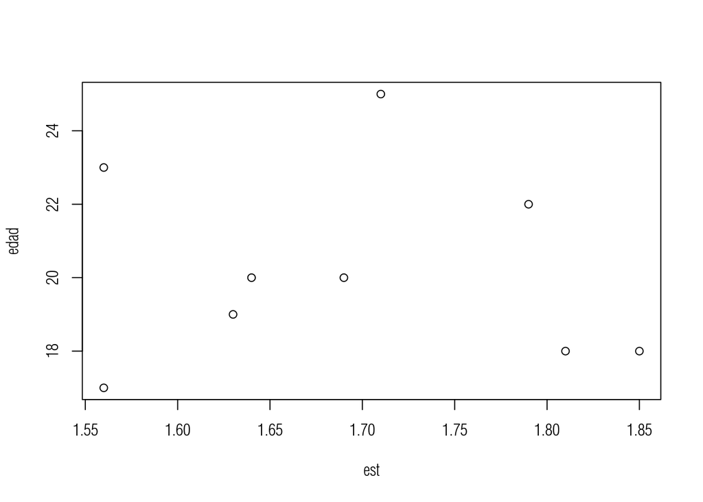

```r
plot(est, edad)
```

Podemos darle formato a los gráficos nativos en R de la siguiente forma:

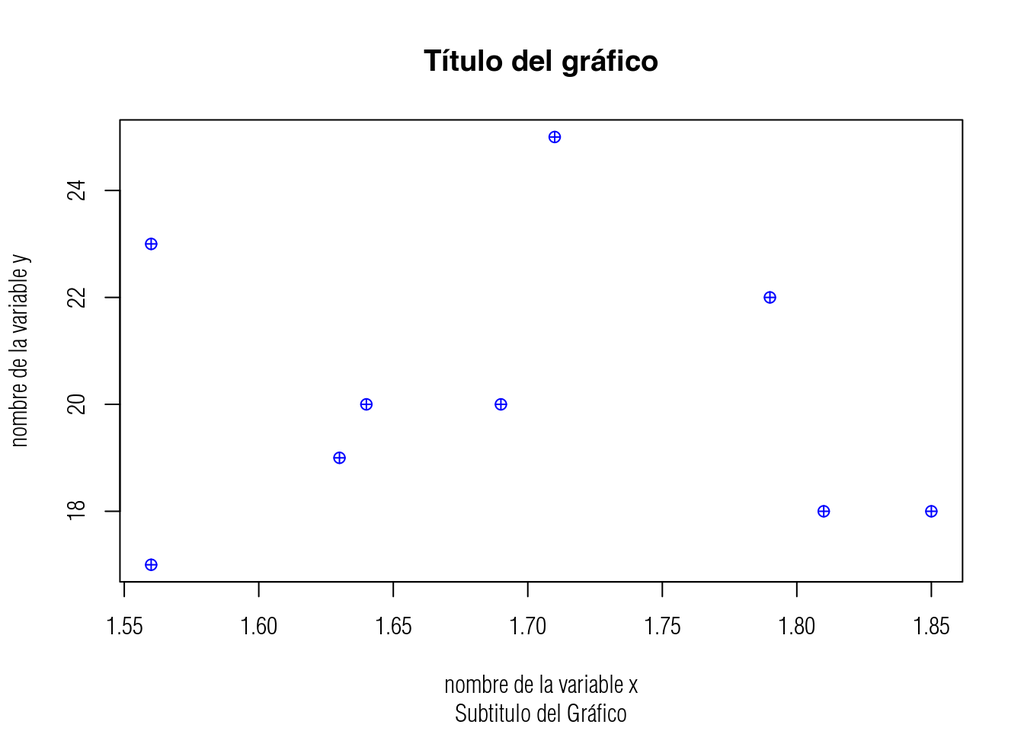

```r
plot(est, edad,
     type = "p",
     pch = 10,
     col = "blue",
     main = "Título del gráfico",
     sub= "Subtitulo del Gráfico",
     xlab = "nombre de la variable x",
     ylab = "nombre de la variable y")
```

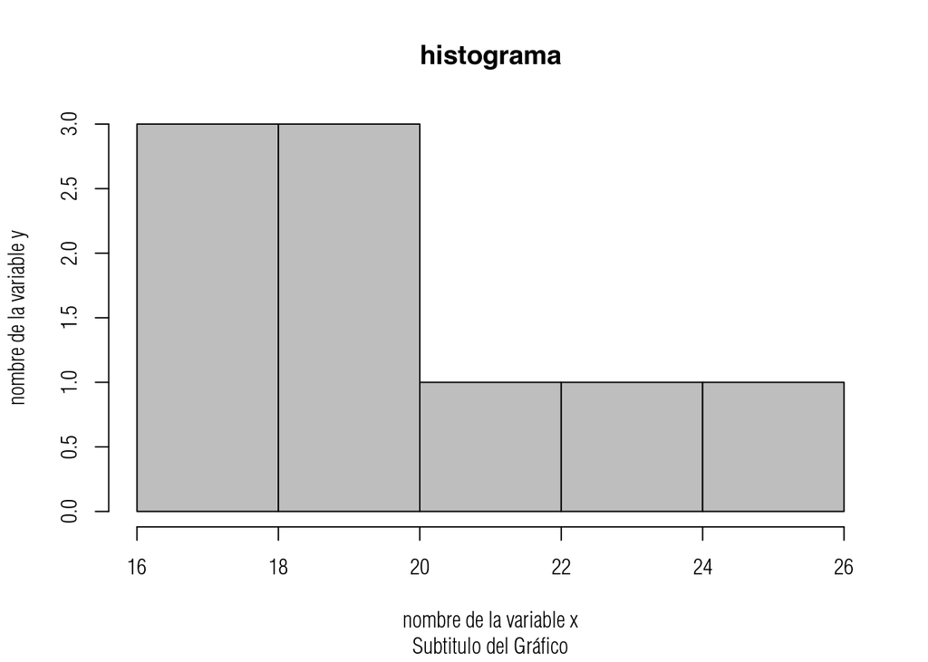

```r
# histograma
hist(edad,
     col = "gray",
     main = "histograma",
     sub= "Subtitulo del Gráfico",
     xlab = "nombre de la variable x",
     ylab = "nombre de la variable y")
```

Para utilizar el gráfico de barras o el gráfico de pastel se realiza una tabla con el comando `table()` ya que se trata de datos categóricos.

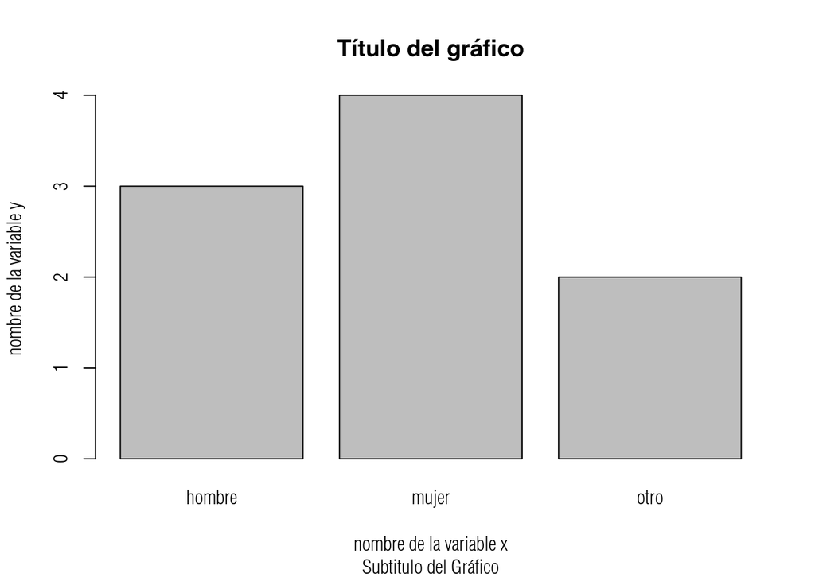

```r
#Gráfico de barras
barplot(table(sexo),
     main = "Título del gráfico",
     sub= "Subtitulo del Gráfico",
     xlab = "nombre de la variable x",
     ylab = "nombre de la variable y")
```

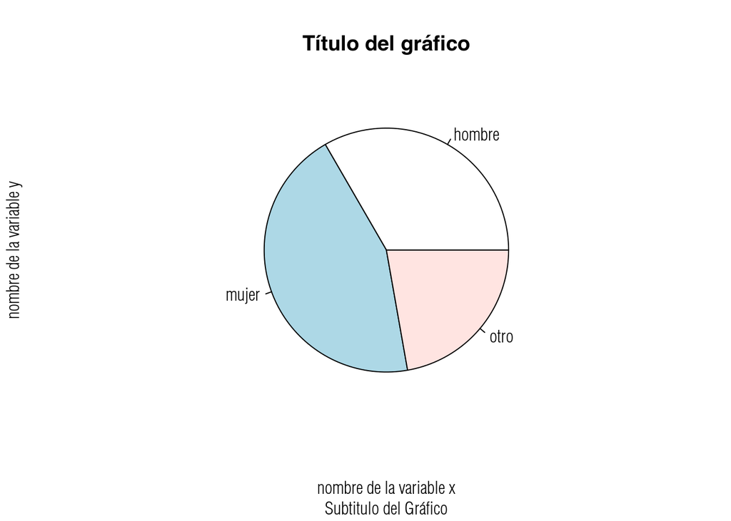

```r
#Gráfico de pastel
pie(table(sexo),
     main = "Título del gráfico",
     sub= "Subtitulo del Gráfico",
     xlab = "nombre de la variable x",
     ylab = "nombre de la variable y")
```

Para realizar un el gráfico de cajas, enfrentamos una variable categórica contra una variable continua, es por eso que se expresa como un modelo, es decir, utilizamos el simbolo `~`.

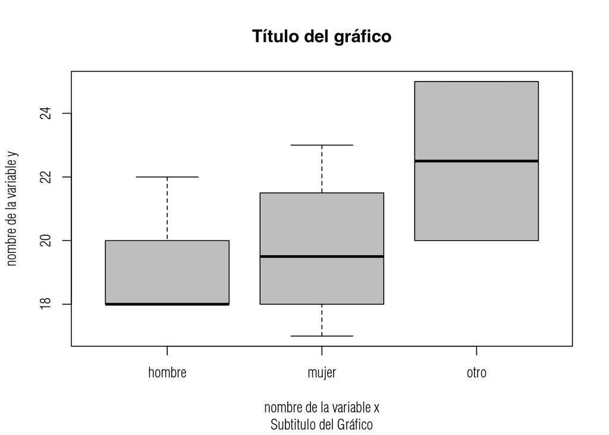

```r
#Gráfico de Cajas
boxplot(edad~sexo,
     col = "gray",
     main = "Título del gráfico",
     sub= "Subtitulo del Gráfico",
     xlab = "nombre de la variable x",
     ylab = "nombre de la variable y")
```

Para hacer gráficos de lineas podemo utilizar tambien la función `plot()`. Con el comando `rnorm()` podemos generar numeros aleatorios basados en la distribución normal.

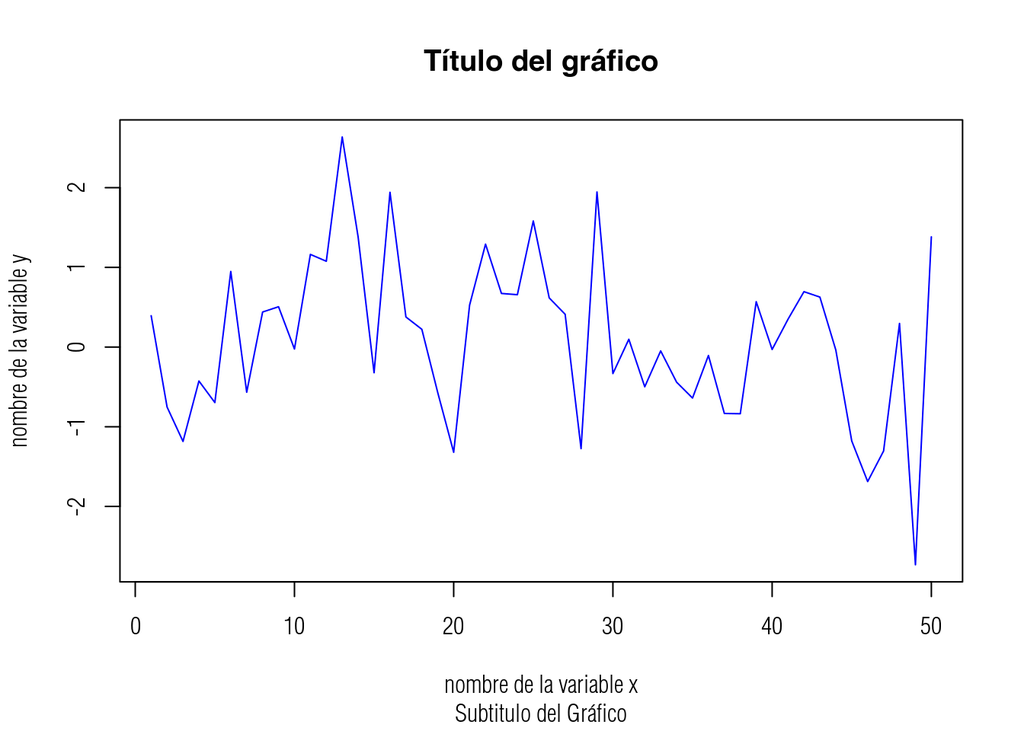

```r
x<-rnorm(50, 0, 1) #media 0, varianza 1
plot(x,
     type = "l",
     col = "blue",
     main = "Título del gráfico",
     sub= "Subtitulo del Gráfico",
     xlab = "nombre de la variable x",
     ylab = "nombre de la variable y")
```

## Aplicación: Calculo de mínimos cuadrados ordinarios

Apliquemos parte de los aprendido, realicemos el calculo de regresión lineal mediante un modelo por aproximación de mínimos cuadrados ordinarios $\mathbf{y =\theta x + \epsilon}$. Este modelo se basa en aproximar una variable minimizando el error cuadrático. primero definamos la matriz de coeficientes:

```r
x <-c(600, 600, 700, 700, 700, 900, 950, 950) #variable independiente
i <-c(1,1,1,1,1,1,1,1)
X <-cbind(i,x) #Matriz de coeficientes
print(X)
```

```
##      i   x
## [1,] 1 600
## [2,] 1 600
## [3,] 1 700
## [4,] 1 700
## [5,] 1 700
## [6,] 1 900
## [7,] 1 950
## [8,] 1 950
```

```r
y <-c(40, 44, 48, 46, 50, 48, 46, 45) #variable de respuesta
```

El vector $\mathbf{\theta}$ que minimizan el error cuadrático medio se calcula evaluando $\mathbf{\theta=(X'X)^{-1}X'y}$ se calculo así:

```r
#Transponer
Xt<-t(X)
#Producto Matricial
B<-Xt%*%X
#Invertir la matriz
C<-solve(B)
#Producto matricial
D<-C%*%Xt
u<-D%*%y
print(u)
```

```
##           [,1]
## i 40.853658537
## x  0.006585366
```

En la práctica, la solución del modelo de mínimos cuadrados se hace mediante el comando `lm()` de la siguiente manera:

```r
m <- lm(y~x)
summary(m)
```

```
##
## Call:
## lm(formula = y ~ x)
##
## Residuals:
##     Min      1Q  Median      3Q     Max
## -4.8049 -1.3598 -0.1341  1.5488  4.5366
##
## Coefficients:
##              Estimate Std. Error t value Pr(>|t|)
## (Intercept) 40.853659   6.156123   6.636 0.000565 ***
## x            0.006585   0.007943   0.829 0.438812
## ---
## Signif. codes:  0 '***' 0.001 '**' 0.01 '*' 0.05 '.' 0.1 ' ' 1
##
## Residual standard error: 3.115 on 6 degrees of freedom
## Multiple R-squared:  0.1028, Adjusted R-squared:  -0.04676
## F-statistic: 0.6873 on 1 and 6 DF,  p-value: 0.4388
```

Para realizar el gráfico utilizamos `plot()`

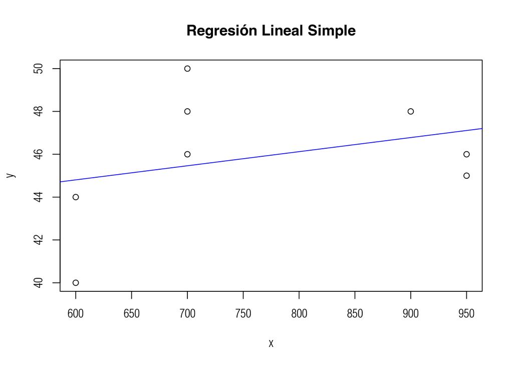

```r
plot(x,y, type = "p",
     xlab = "x",
     ylab = "y",
     main="Regresión Lineal Simple")
abline(m, col="blue")
```

Realicemos ahora el mismo ejercicio matricial pero agreguemos un ajuste cuadrático:

```r
x <-c(600, 600, 700, 700, 700, 900, 950, 950) #variable independiente
i <-c(1,1,1,1,1,1,1,1)
x2 <- x^2
X <-cbind(i,x, x2) #Matriz de coeficientes
y <-c(40, 44, 48, 46, 50, 48, 46, 45) #variable de respuesta
#Transponer
Xt<-t(X)
#Producto Matricial
B<-Xt%*%X
#Invertir la matriz
C<-solve(B)
#Producto matricial
D<-C%*%Xt
u<-D%*%y
print(u)
```

```
##        [,1]
## i  -78.0000
## x    0.3200
## x2  -0.0002
```

La grafica correspondiente se puede hacer mediante el comando `curve()`. Se espesifica con `from =` y `to =` los límites de la curva en el eje de las x. Con `add =` especificamos si se quiere superponer a la gráfica anterior.:

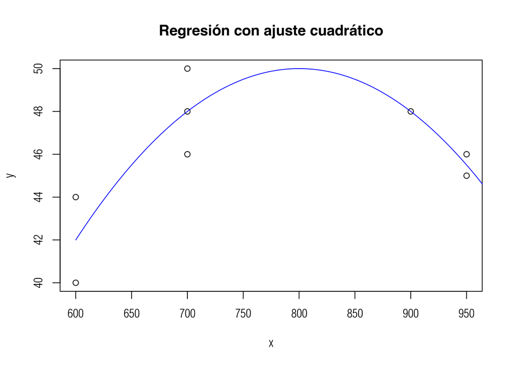

```r
plot(x,y, type = "p", xlab = "x", ylab = "y",
     main="Regresión con ajuste cuadrático")
b<-curve(u[1]+u[2]*x + u[3]*x^2, from = 600, to=1000, add = TRUE, col="blue")
```

Este ajuste cuadrático para este caso es mejor que el ajuste lineal.

## Funciones

En R se pueden declarar funciones para facilitar el trabajo cuando una instrucción debe ser repetida a lo largo del código, ejemplo de esto es el uso en funciones matemáticas o en métodos de optimización. Por ejemplo, para definir la función $f(x)=x^{2} + 2\cos(x)$ realizamos lo siguiente:

```r
f1 <- function(x){
  return(x**2 + 2*cos(x))
}
```

Para evaluar la función basta con asignar un valor a x:

```r
a<-f1(10)
a
```

```
## [1] 98.32186
```

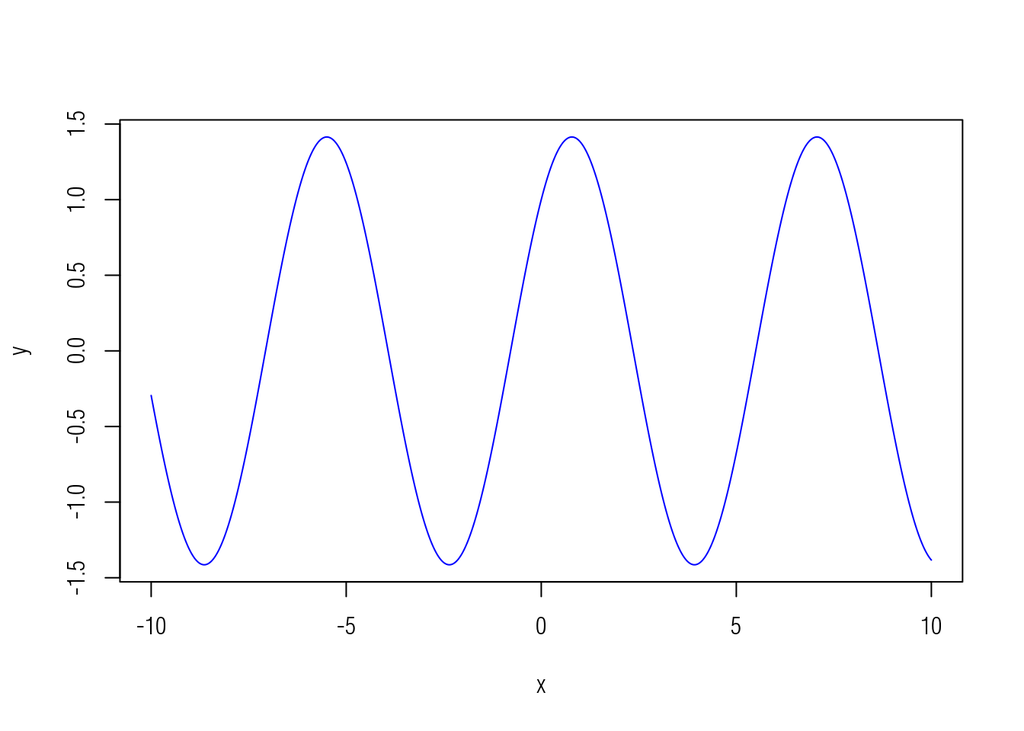

```r
f1 <- function(x){
  return(sin(x)+cos(x))
}
x<-seq(-10,10,0.01)
y <- f1(x)
plot(x,y, type = "l", col = "blue")
```

Las listas son utilizadas en muchas ocaciones dentro de una función ya que esta puede almacenar distintos tipos de datos:

```r
lista<-list(nombre = "elias", edad = 21, calificaciones = c(10,9,8.5,10,9))
lista
```

```
## $nombre
## [1] "elias"
##
## $edad
## [1] 21
##
## $calificaciones
## [1] 10.0  9.0  8.5 10.0  9.0
```

Para acceder a un elemento dentro de una lista podemos utilizar el simbolo `$` despues del nombre de la lista o utilizar corchetes `[ ]`. El doble corchete `[[ ]][ ]` se utiliza cuando se buscan elementos de un vector dentro de una lista:

```r
lista$nombre
```

```
## [1] "elias"
```

```r
lista$edad
```

```
## [1] 21
```

```r
lista$calificaciones
```

```
## [1] 10.0  9.0  8.5 10.0  9.0
```

```r
lista[3]
```

```
## $calificaciones
## [1] 10.0  9.0  8.5 10.0  9.0
```

```r
lista[[3]][1]
```

```
## [1] 10
```

Al utilizar funciones se suelen utilizar estructuras de control. Además de condicionales o ciclos podemos utilizar `switch()` el cual permite ejecutar alguna orden dentro de un conjunto dependiendo de si una condición se ha cumplido. Por ejemplo, se desea calcular el valor máximo o mínimo de un vector dependiendo de una condición previa:

```r
v <- runif(20, -10, 10)
type = "minimo"
switch(type, minimo = min(v), maximo = max(v))
```

```
## [1] -9.178548
```

```r
type = "maximo"
switch(type, minimo = min(v), maximo = max(v))
```

```
## [1] 9.782508
```

Se puede utilizar `stop()` para detener un proceso al cumplirse una condición:

```r
a <- 5
b <-c(1,2,3,5,5)
if (a %in% b == TRUE){
  stop("a esta en b")
}

# Error: a esta en b
```

## Aplicación: Método Newton-Raphson

El método de Newton-Raphson es utilizado para encontrar la aproximación a los ceros o raices de una función. También puede ser un método de optimización si se aplica sobre la primera derivada de la función.

Sea $F(x)$ una función definida en el intervalo $[a, b]$ se puede cumplir que:
$$x_{n+1} = x_{n} - \frac{F(x_{n})}{F'(x_{n})}$$
donde $F'$ define a la primera derivada. Este método al ser iterativo puede iterar de manera indefinida hasta llegar a la raíz que se busca. Para ajustar el método es necesario aplicar un máximo de iteraciones y una tolerancia, es decir, un margen de error aceptable.

```r
NewtonR <- function(Fx, dFx, x0, iter, tol ){
  #Fx   - Función a utilizar.
  #dFx  - Primera derivada de la función.
  #X0   - Valor inicial
  #iter - Máximo de iteraciones
  #tol  - tolerancia máxima.
  if (iter > 100){
    stop("Son demasiadas iteraciones")
  }
  for(i in 1:iter){
    ratio <- Fx(x0)/dFx(x0)
    x = x0 - ratio
    if(abs(x - x0) < tol){
      return(x)
      i = iter
    }
    else{
      i + 1
      x0 = x
    }
  }
}
```

Damos ahora los valores iniciales:

```r
x0 = 2
Fx <- function(x){ #función a evaluar
  return(x^3 + 4*x^2 - 10)
}
dFx <- function(x){  #Derivada de la función
  return(3 * x^2 +8 * x )
}
iter <- 50
tol <- 1e-6 #Tolerancia de 0.000001
raiz <- NewtonR(Fx, dFx, x0, iter, tol)
print(paste("x: ", raiz))
```

```
## [1] "x:  1.3652300134141"
```

Calculamos ahora su respectivo gráfico:

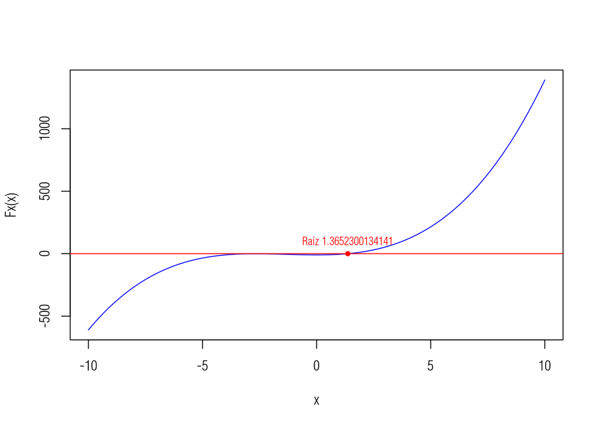

```r
x <- seq(-10 , 10, 0.01) #dominio de x
plot(x, Fx(x), type = "l", col = "blue")
points(raiz, Fx(raiz), col="red", pch=20) #colocamo un punto en la raíz
abline(h = 0, col = "red") #Linea del cero
text(raiz, Fx(raiz), paste("Raiz", raiz) , cex=0.8, pos=3,col="red") #texto
```

Cualquier duda o comentario, escriba a iranapolinar@hotmail.com